# Project 4: Red Wine Analysis

# Introduction

The analysis that follows is based on the following dataset: P. Cortez, A. Cerdeira, F. Almeida, T. Matos and J. Reis. Modeling wine preferences by data mining from physicochemical properties. In Decision Support Systems, Elsevier, 47(4):547-553. ISSN: 0167-9236.

## An overview of the data

Following are the variables included in the Red Wine dataset:

```
##  [1] "X"                    "fixed.acidity"        "volatile.acidity"
##  [4] "citric.acid"          "residual.sugar"       "chlorides"
##  [7] "free.sulfur.dioxide"  "total.sulfur.dioxide" "density"
## [10] "pH"                   "sulphates"            "alcohol"
## [13] "quality"
```

where variables are of type:

```
## 'data.frame':    1599 obs. of  13 variables:
##  $ X                   : int  1 2 3 4 5 6 7 8 9 10 ...
##  $ fixed.acidity       : num  7.4 7.8 7.8 11.2 7.4 7.4 7.9 7.3 7.8 7.5 ...
##  $ volatile.acidity    : num  0.7 0.88 0.76 0.28 0.7 0.66 0.6 0.65 0.58 0.5 ...
##  $ citric.acid         : num  0 0 0.04 0.56 0 0 0.06 0 0.02 0.36 ...
##  $ residual.sugar      : num  1.9 2.6 2.3 1.9 1.9 1.8 1.6 1.2 2 6.1 ...
##  $ chlorides           : num  0.076 0.098 0.092 0.075 0.076 0.075 0.069 0.065 0.073 0.071 ...
##  $ free.sulfur.dioxide : num  11 25 15 17 11 13 15 15 9 17 ...
##  $ total.sulfur.dioxide: num  34 67 54 60 34 40 59 21 18 102 ...
##  $ density             : num  0.998 0.997 0.997 0.998 0.998 ...
##  $ pH                  : num  3.51 3.2 3.26 3.16 3.51 3.51 3.3 3.39 3.36 3.35 ...
##  $ sulphates           : num  0.56 0.68 0.65 0.58 0.56 0.56 0.46 0.47 0.57 0.8 ...
##  $ alcohol             : num  9.4 9.8 9.8 9.8 9.4 9.4 9.4 10 9.5 10.5 ...
##  $ quality             : int  5 5 5 6 5 5 5 7 7 5 ...
```

Thus it looks like X variable is just an index.

Now Let’s look at the variability in the variables:

```
##  fixed.acidity   volatile.acidity  citric.acid    residual.sugar
##  Min.   : 4.60   Min.   :0.1200   Min.   :0.000   Min.   : 0.900
##  1st Qu.: 7.10   1st Qu.:0.3900   1st Qu.:0.090   1st Qu.: 1.900
##  Median : 7.90   Median :0.5200   Median :0.260   Median : 2.200
##  Mean   : 8.32   Mean   :0.5278   Mean   :0.271   Mean   : 2.539
##  3rd Qu.: 9.20   3rd Qu.:0.6400   3rd Qu.:0.420   3rd Qu.: 2.600
##  Max.   :15.90   Max.   :1.5800   Max.   :1.000   Max.   :15.500
##    chlorides       free.sulfur.dioxide total.sulfur.dioxide
##  Min.   :0.01200   Min.   : 1.00       Min.   :  6.00
##  1st Qu.:0.07000   1st Qu.: 7.00       1st Qu.: 22.00
##  Median :0.07900   Median :14.00       Median : 38.00
##  Mean   :0.08747   Mean   :15.87       Mean   : 46.47
##  3rd Qu.:0.09000   3rd Qu.:21.00       3rd Qu.: 62.00
##  Max.   :0.61100   Max.   :72.00       Max.   :289.00
##     density             pH          sulphates         alcohol
##  Min.   :0.9901   Min.   :2.740   Min.   :0.3300   Min.   : 8.40
##  1st Qu.:0.9956   1st Qu.:3.210   1st Qu.:0.5500   1st Qu.: 9.50
##  Median :0.9968   Median :3.310   Median :0.6200   Median :10.20
##  Mean   :0.9967   Mean   :3.311   Mean   :0.6581   Mean   :10.42
##  3rd Qu.:0.9978   3rd Qu.:3.400   3rd Qu.:0.7300   3rd Qu.:11.10
##  Max.   :1.0037   Max.   :4.010   Max.   :2.0000   Max.   :14.90
##     quality
##  Min.   :3.000
##  1st Qu.:5.000
##  Median :6.000
##  Mean   :5.636
##  3rd Qu.:6.000
##  Max.   :8.000
```

We can also visualize the variability of each variable by plotting a boxplot for each:

```
## Using  as id variables
```

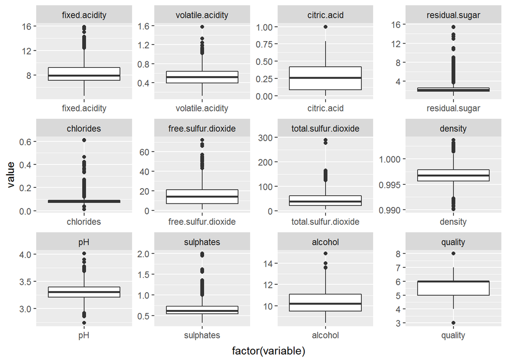

The upper and lower whiskers extend to the highest and lowest point whithin 1.5* the inter-quartile range.

We can also plot histograms for each variable to help us understand the distribution of each variable:

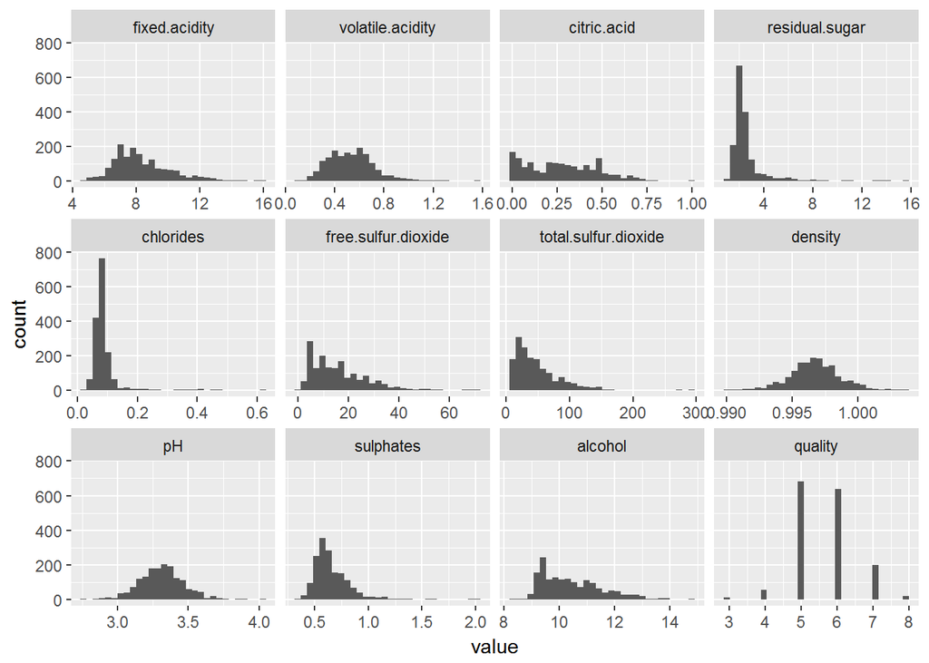

[figure not shown]

Here are the summary statistics for residual sugar:

```
##    Min. 1st Qu.  Median    Mean 3rd Qu.    Max.
##   0.900   1.900   2.200   2.539   2.600  15.500
```

And chlorides:

```
##    Min. 1st Qu.  Median    Mean 3rd Qu.    Max.
## 0.01200 0.07000 0.07900 0.08747 0.09000 0.61100
```

What we are most interested in is the quality rating and what variables influence the quality rating. Let’s take a look at the red wine quality ratings using a histogram.

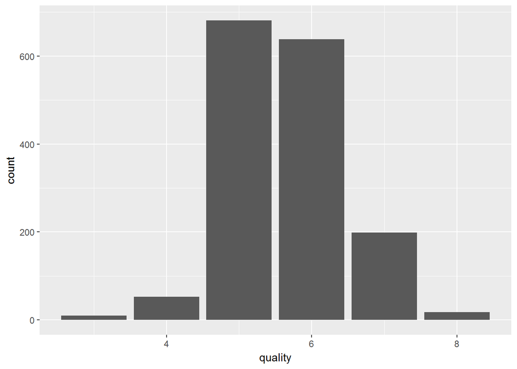

```
##    Min. 1st Qu.  Median    Mean 3rd Qu.    Max.
##   3.000   5.000   6.000   5.636   6.000   8.000
```

The vast majority of red wines have a quality ranking of 5 and 6.

The alcohol content can be another important consideration when we are purchasing wine:

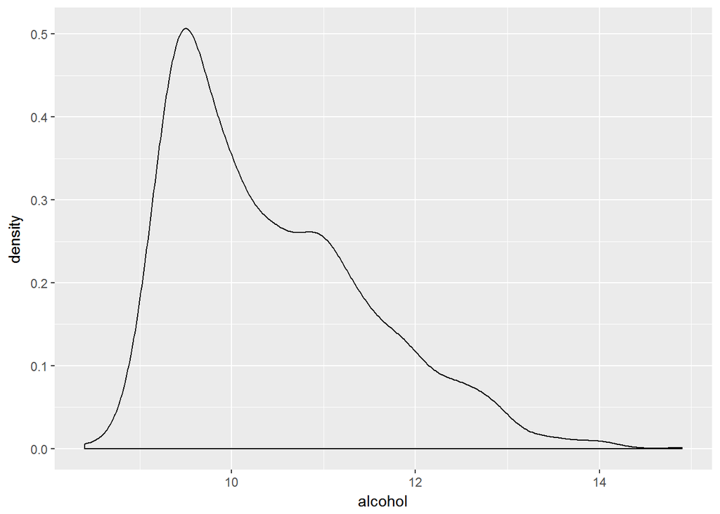

```
##    Min. 1st Qu.  Median    Mean 3rd Qu.    Max.
##    8.40    9.50   10.20   10.42   11.10   14.90
```

It looks like the alcohol content of the wine in the dataset follows a lognormal distribution with a high peak at the lower end of the alcohol scale.

## Bivariate relationships

We can quickly visualize the relationship between each pair of variables and find their pearson product-moment correlation. The names along the x and y axis of the plot matrix below are as follows:

```
##  [1] "fixed.acidity"        "volatile.acidity"     "citric.acid"
##  [4] "residual.sugar"       "chlorides"            "free.sulfur.dioxide"
##  [7] "total.sulfur.dioxide" "density"              "pH"
## [10] "sulphates"            "alcohol"              "quality"
```

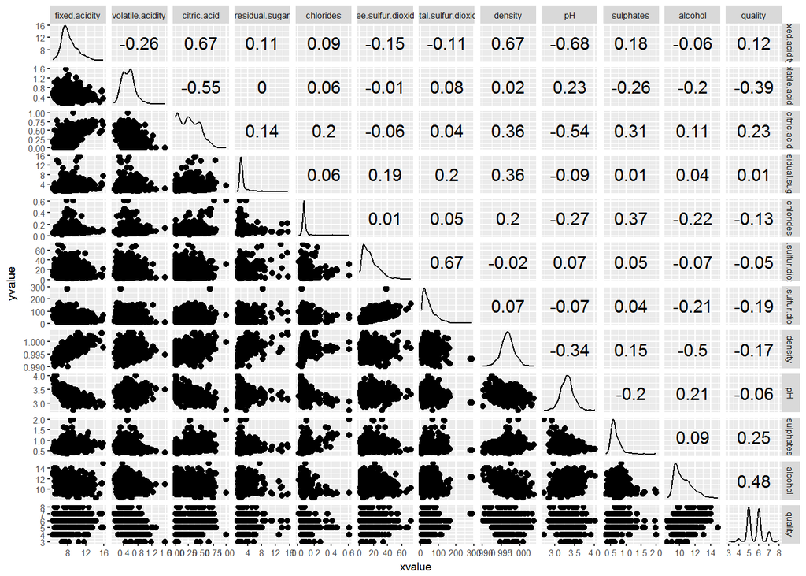

The top 4 correlation coefficients with quality are:

- alchol:quality = 0.48
- sulphates:quality = 0.25
- citric.acid:quality = 0.23
- fixed.acidity:quality = 0.12

So as we saw earlier, alcohol content has a high correlation with red wine quality. Other important attributes correlated with red wine quality include sulphates, citric acid and fixed acidity. According to [wikipedia](http://en.wikipedia.org/wiki/Acids_in_wine), most of the acids involved with wine making are fixed acids except of acetic acid which is volatile and contributes to “a wine fault known as volatility”.

The biggest negative corrlation coefficients with quality are:

- volatile.acidity:quality = -0.39
- total.sulfur.dioxide:quality = -0.19
- density:quality = -0.17
- chlorides:quality = -0.13

So we see that volatile acids are negatively correlated with red wine quality. Tota sulfur dioxide, density and chlorides are also negatively correlated with quality.

Variables with the highest (positive or negative) correlation include:

- fixed.acidity:citirc.acid = 0.67
- fixed.acidity:density = 0.67
- free.sulfur.dioxide:total.sulfur.dioxide = 0.67
- alcohol:quality = 0.48
- density:alcohol = -0.50
- citric.acid:pH = -0.54
- volatile.acidity:citirc.acid = -0.55
- fixed.acidity:pH = -0.68

Let’s look at a few of these relationships in a bit more detail. Density and alcohol:

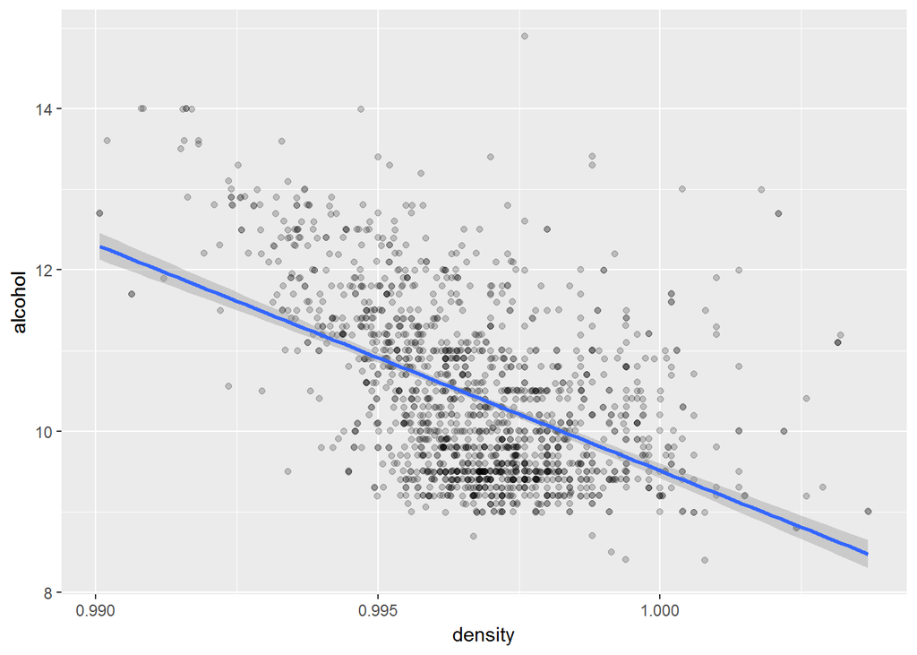

We see that density tends to increase with decreasing alcohol content.

Fixed acidity and pH:

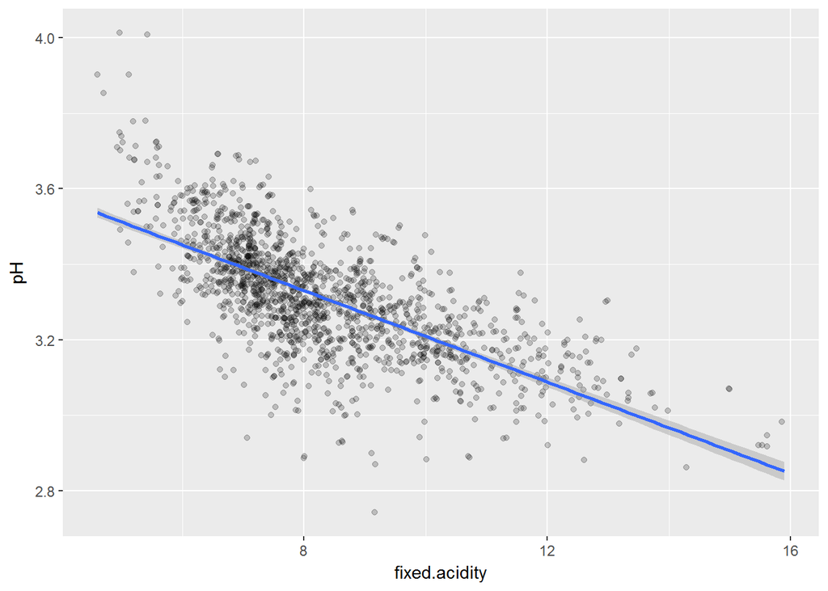

We also see fixed acidity increase as pH decreases.

Fixed acidity and density:

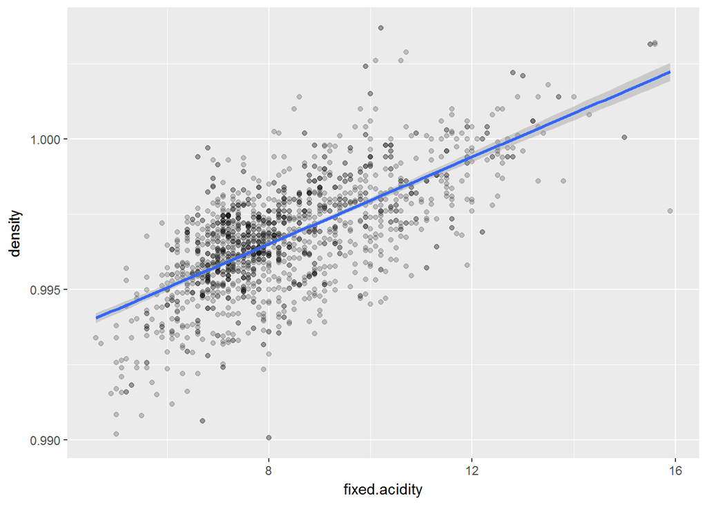

On the other hand fixed acidity increases with density.

Now let’s look at the alcohol content by red wine quality using a density plot function:

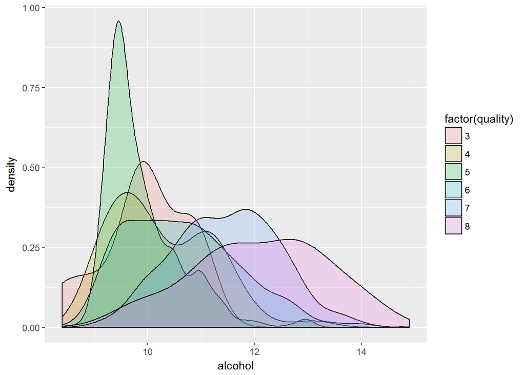

It looks like the red wines with a higher alcohol content tend to have a higher quality rating…what a surprise! The main anomoly to this trend appears to be red wines having a quality ranking of 5.

Here are the summary statistics for alcohol content at each quality level:

```
## factor(wine$quality): 3
##    Min. 1st Qu.  Median    Mean 3rd Qu.    Max.
##   8.400   9.725   9.925   9.955  10.575  11.000
## --------------------------------------------------------
## factor(wine$quality): 4
##    Min. 1st Qu.  Median    Mean 3rd Qu.    Max.
##    9.00    9.60   10.00   10.27   11.00   13.10
## --------------------------------------------------------
## factor(wine$quality): 5
##    Min. 1st Qu.  Median    Mean 3rd Qu.    Max.
##     8.5     9.4     9.7     9.9    10.2    14.9
## --------------------------------------------------------
## factor(wine$quality): 6
##    Min. 1st Qu.  Median    Mean 3rd Qu.    Max.
##    8.40    9.80   10.50   10.63   11.30   14.00
## --------------------------------------------------------
## factor(wine$quality): 7
##    Min. 1st Qu.  Median    Mean 3rd Qu.    Max.
##    9.20   10.80   11.50   11.47   12.10   14.00
## --------------------------------------------------------
## factor(wine$quality): 8
##    Min. 1st Qu.  Median    Mean 3rd Qu.    Max.
##    9.80   11.32   12.15   12.09   12.88   14.00
```

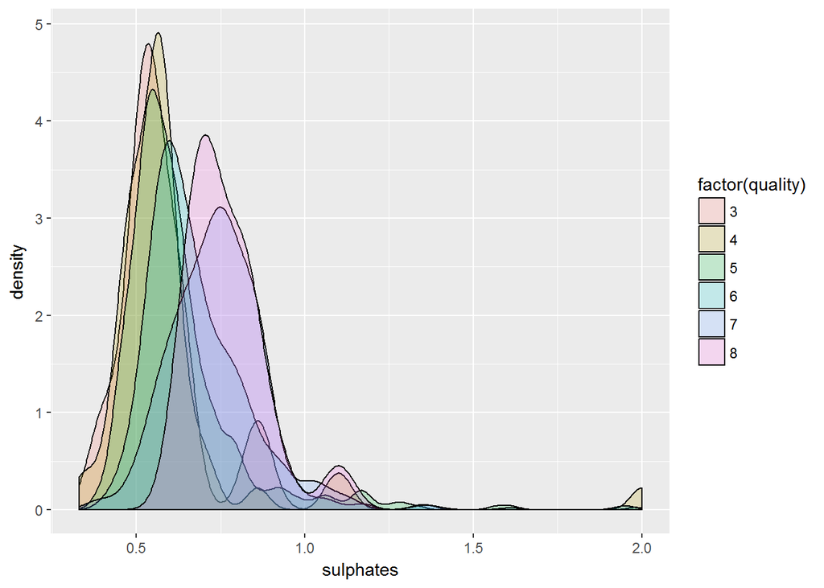

It looks like sulphate content is quite important for red wine quality, particularly for the highest quality levels including quality 7 and 8.

And here are the summary statistics for sulphates at each quality level:

```
## $`3`
##    Min. 1st Qu.  Median    Mean 3rd Qu.    Max.
##  0.4000  0.5125  0.5450  0.5700  0.6150  0.8600
##
## $`4`
##    Min. 1st Qu.  Median    Mean 3rd Qu.    Max.
##  0.3300  0.4900  0.5600  0.5964  0.6000  2.0000
##
## $`5`
##    Min. 1st Qu.  Median    Mean 3rd Qu.    Max.
##   0.370   0.530   0.580   0.621   0.660   1.980
##
## $`6`
##    Min. 1st Qu.  Median    Mean 3rd Qu.    Max.
##  0.4000  0.5800  0.6400  0.6753  0.7500  1.9500
##
## $`7`
##    Min. 1st Qu.  Median    Mean 3rd Qu.    Max.
##  0.3900  0.6500  0.7400  0.7413  0.8300  1.3600
##
## $`8`
##    Min. 1st Qu.  Median    Mean 3rd Qu.    Max.
##  0.6300  0.6900  0.7400  0.7678  0.8200  1.1000
```

## Multivariate Plots

Now let’s visualize the relationship between sulphates, volatile.acidity, alcohol and quality:

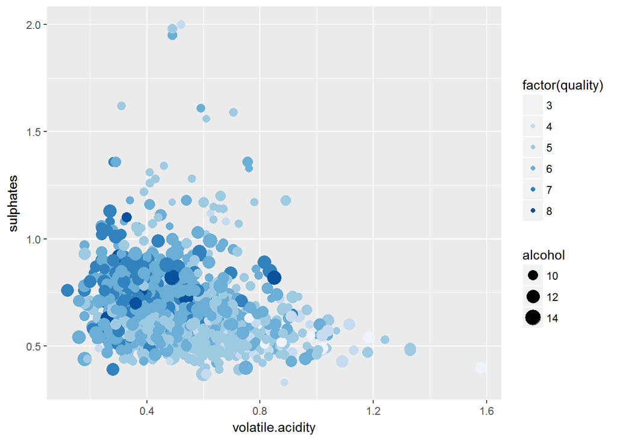

It looks like the higher quality red wines tend to be concentrated in the top left of the plot. This tends to be where the higher alcohol content (larger dots) are concentrated as well.

Let’s try summarizing quality using a contour plot of alcohol and sulphate content:

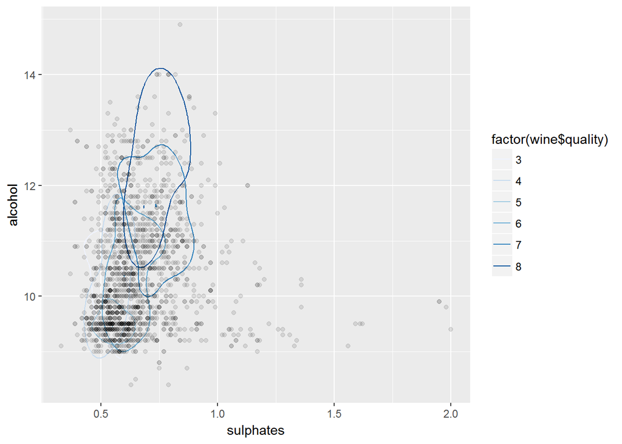

Let’s make a similar plot but this time quality will be visualized using density plots along the x and y axis and color :

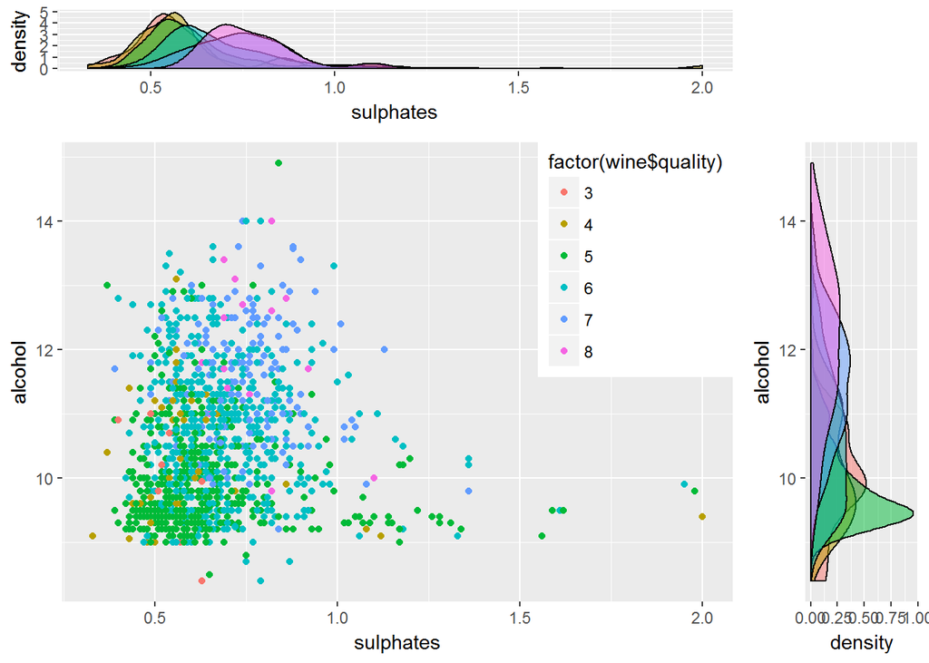

Again, this clearly illustrates that higher quality wines are found near the top right of the plot.

# Final Plots & Summary

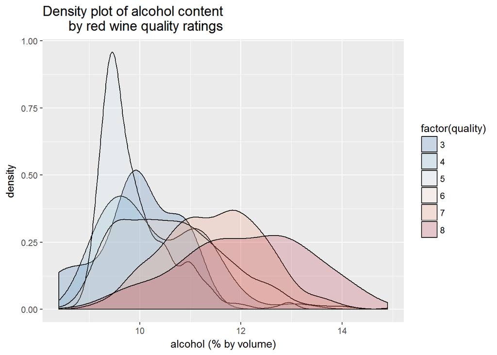

We can see that the density plots for higher quality red wines (as indicated by the red plots) are right shifted, meaning they have a comparatively high alcohol content. However, the main anomaly to this trend appears to be red wines having a quality ranking of 5.

Here are the summary statistics for alcohol content at each quality level:

```
## wine$quality: 3
##    Min. 1st Qu.  Median    Mean 3rd Qu.    Max.
##   8.400   9.725   9.925   9.955  10.575  11.000
## --------------------------------------------------------
## wine$quality: 4
##    Min. 1st Qu.  Median    Mean 3rd Qu.    Max.
##    9.00    9.60   10.00   10.27   11.00   13.10
## --------------------------------------------------------
## wine$quality: 5
##    Min. 1st Qu.  Median    Mean 3rd Qu.    Max.
##     8.5     9.4     9.7     9.9    10.2    14.9
## --------------------------------------------------------
## wine$quality: 6
##    Min. 1st Qu.  Median    Mean 3rd Qu.    Max.
##    8.40    9.80   10.50   10.63   11.30   14.00
## --------------------------------------------------------
## wine$quality: 7
##    Min. 1st Qu.  Median    Mean 3rd Qu.    Max.
##    9.20   10.80   11.50   11.47   12.10   14.00
## --------------------------------------------------------
## wine$quality: 8
##    Min. 1st Qu.  Median    Mean 3rd Qu.    Max.
##    9.80   11.32   12.15   12.09   12.88   14.00
```

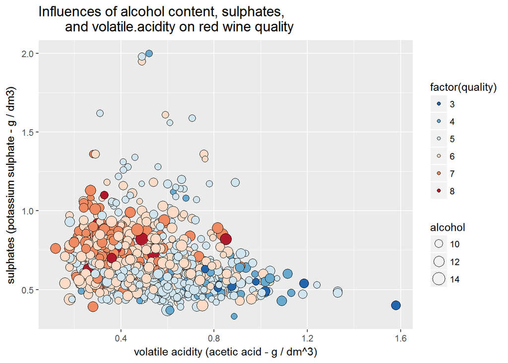

We can also visualize the relationship between alcohol content and sulphates by combining scatter plots with density plots:

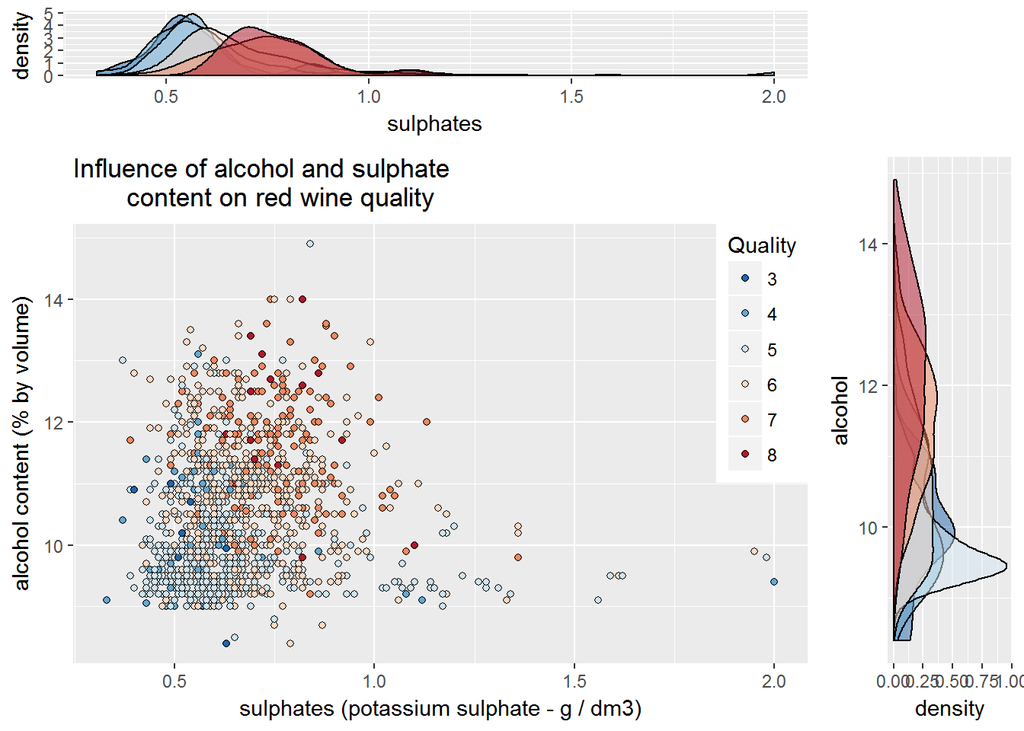

# Reflection

My major worry was to wrangle a dataset in to a tidy datset. Thus I chose one of the recommended datasets.

GGally provides a concise summary of the pairwise relationships in the dataset.

It was usefull to use the insights from correlation coefficients provided by the paired plots to explore quality using density plots with a different color for each quality. It helped tp make multivariate scatter plots to visualize the relationship of different variables with quality next I think we should develop a statistical model to predict red wine quality based on the data in this dataset.